# Introduction to R programming - Week one

Jennifer Guthrie, Idowu Olawoye

Last modified: 04 Jan 2024

# Course Aims

- Knowing what R is all about
- Understand different Data Types and Structures
- Manipulate data structures and Dataframes
- Execute Basic Arithmetic Operations

# 1. Introduction to R and its environment

## What is R?

- A statistical programming environment
  - based on ‘S’
  - suited to high-level data analysis
- But offers much more than just statistics
- Open source and cross platform
- Extensive graphics capabilities
- Diverse range of add-on packages
- Active community of developers
- Thorough documentation

http://www.r-project.org/

[figure not shown]

R logo

## Examples of R plotting capabilities

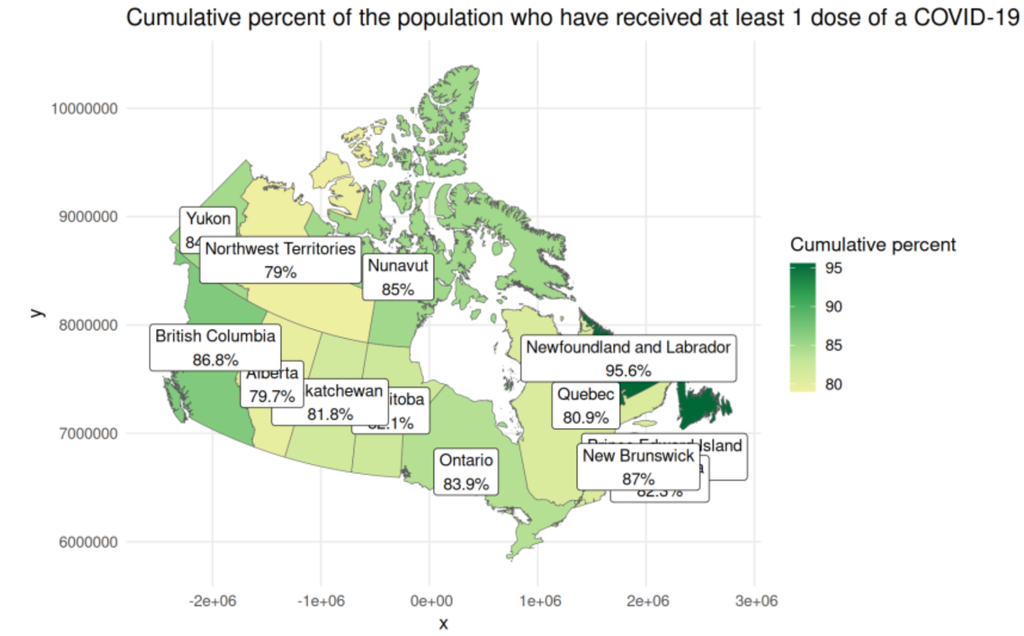

Canada COVID-19 vaccination map with different projections

https://www.r-bloggers.com/2023/08/plotting-a-covid-19-vaccination-map-with-different-projections-with-updated-versions-of-canadamaps-and-tintin/

## Who uses R? Not just Academics

[figure not shown]

Companies that use R

## Getting Started - Latest Release 4.3.2 (October 31, 2023)

Using the CRAN mirror available for Canada, Manitoba Unix User Group:

- [Download R for Linux](https://muug.ca/mirror/cran/bin/linux/)
- [Download R for MacOS](https://muug.ca/mirror/cran/bin/macosx/)
- [Download R for Windows](https://muug.ca/mirror/cran/bin/windows/)

Once R base has been successfully installed, proceed to install [RStudio](https://posit.co/download/rstudio-desktop/)

- The traditional way to enter R commands is via the Terminal, or using the console in RStudio (bottom-left)
- However, for this course we will use a relatively new feature called *R-notebooks*.
- An R-notebook mixes plain text with R code
  - The R code can be run from inside the document and the results are displayed directly underneath
- Each *chunk* of R code looks something like this.
- Each line of R can be executed by clicking on the line and pressing CTRL and ENTER
- Or you can press the green triangle on the right-hand side to run everything in the chunk
- Try this now!

```r
print("Hello World")
```

## 1.1. Variables and Data Structures

Variables are objects that can be used to store data in R. Data structures can also come in different formats such as characters, integers, numeric, vectors, and so on. Take for example:

```r
x <- "dataset"
x
typeof(x)
```

Another example is:

```r
y <- 1:10
y
typeof(y)
```

Let’s try this trick by converting the variable y and storing it as a different variable:

```r
z <- as.numeric(y)
z
typeof(z)
```

We can change the value of an existing variable:

```r
z <- 40.5
z
```

Naming variables is a matter of taste. Some [conventions](http://adv-r.had.co.nz/Style.html) exist such as a separating words with `-` or using *C*amel*C*aps. Whatever convention you decided, stick with it!

## 1.2. Basic Arithmetic Operations

- The command line can be used as a calculator and understands the usual arithmetic operators +, -, *, /
- Try adding a few more calculations here

```r
2 + 2
2 - 2
4 * 3
10 / 2
```

Note: The number in the square brackets is an indicator of the position in the output. In this case the output is a ‘vector’ of length 1 (i.e. a single number). More on vectors coming up…

In the case of expressions involving multiple operations, R respects the [BODMAS](https://en.wikipedia.org/wiki/Order_of_operations#Mnemonics) system to decide the order in which operations should be performed.

```r
2 + 2 * 3
2 + (2 * 3)
(2 + 2) * 3
```

R is capable of more complicated arithmetic such as trigonometry and logarithms; like you would find on a fancy scientific calculator. Of course, R also has a plethora of statistical operations as we will see.

```r
pi
sin (pi/2)
cos(pi)
tan(2)
log(1)
```

We can also perform arithmetic on variables

```r
myNumber <- 25
myNumber
sqrt(myNumber)
```

We can add variables together

```r
newNum <- 10
newNum
Total <- newNum + sqrt(myNumber)
Total
```

Dealing with Errors! What if we did this instead?

```r
newNum <- 10
newNum
Total <- newNum + sqrt(myNumbr)
Total
```

## 1.3. Functions

- **Functions** in R perform operations on **arguments** (the inputs(s) to the function). We have already used:

```r
sin(x)
```

- This returns the sine of x
  - In this case the function has one argument: **x**.
  - Arguments are always contained in parentheses – curved brackets, **()** – separated by commas.

Arguments can be named or unnamed, but if they are unnamed they must be ordered (we will see later how to find the right order). The names of the arguments are determined by the author of the function and can be found in the help page for the function. When testing code, it is easier and safer to name the arguments.

`seq` is a function for generating a numeric sequence *from* and *to* particular numbers.

- Type `?seq` to get the help page for this function.
- When testing code, it is easier and safer to name the arguments

```r
seq(from = 2, to = 20, by = 4)
seq(2, 20, 4)
```

Arguments can have *default* values, meaning we do not need to specify values for these in order to run the function.

`rnorm` is a function that will generate a series of values from a *normal distribution*. In order to use the function, we need to tell R how many values we want

```r
rnorm(n=10)
```

The normal distribution is defined by a *mean* (average) and *standard deviation* (spread). However, in the above example we didn’t tell R what mean and standard deviation we wanted. So how does R know what to do? All arguments to a function and their default values are listed in the help page

(*N.B sometimes help pages can describe more than one function*)

```r
?rnorm
```

In this case, we see that the defaults for mean and standard deviation are 0 and 1. We can change the function to generate values from a distribution with a different mean and standard deviation using the `mean` and `sd` *arguments*. It is important that we get the spelling of these arguments exactly right, otherwise R will an error message, or (worse?) do something unexpected.

```r
rnorm(n=10, mean=2,sd=3)
rnorm(10, 2, 3)
```

In the examples above, `seq` and `rnorm` were both outputting a series of numbers, which is called a *vector* in R and is the most-fundamental data-type.

## 1.4. Vectors

- The basic data structure in R is a **vector** – an ordered collection of values.
- R treats even single values as 1-element vectors.
- The function **`c`** *combines* its arguments into a vector:

```r
x <- c(3,4,5,6)
x
```

- The square brackets `[]` indicate the position within the vector (the *index*).
- We can extract individual elements by using the `[]` notation:

```r
x[1]
x[4]
```

- We can even put a vector inside the square brackets (*vector indexing*):
- **Before executing this line of code, what do you think it will produce?**

```r
y <- c(2,3)
x[y]
```

- There are a number of shortcuts to create a vector.
- Instead of:

```r
x <- c(3, 4, 5, 6, 7, 8, 9, 10, 11, 12)
x
```

- we can write:

```r
x <- 3:12
x
```

- or we can use the **`seq()`** function, which returns a vector:

```r
x <- seq(2, 20, 4)
x
```

```r
x <- seq(2, 20, length.out=5)
x
```

- or we can use the **`rep()`** function:

```r
y <- rep(3, 5)
y
```

```r
y <- rep(1:3, 5)
y
```

- We have seen some ways of extracting elements of a vector. We can use these shortcuts to make things easier (or more complex!)

```r
x <- 3:12
# Extract elements from x:

x[3:7]
x[seq(2, 6, 2)]
x[rep(3, 2)]
```

- We can add an element to a vector:

```r
y <- c(x, 1)
y
```

- We can glue vectors together:

```r
z <- c(x, y)
z
```

- We can “remove” element(s) from a vector:
  - NOTE: the vector x doesn’t get modified
  - we’re just displaying what the vector looks like without particular elements

```r
x <- 3:12

x[-3]
x[-(5:7)]
x[-seq(2, 6, 2)]
x
```

- Finally, we can modify the contents of a vector:

```r
x[6] <- 4
x

x[3:5] <- 1
x
```

**Remember!**

- **Square** brackets [ ] for *indexing*
- **Parentheses** () for function *arguments*

### 1.4.1 Character vectors and naming

- All the vectors we have seen so far have contained numbers, but we can also store text (/“strings”) in vector
  - this is called a **character** vector.

```r
gene.names <- c("Pax6", "Beta-actin", "FoxP2", "Hox9")
gene.names
```

- We can name elements of vectors using the `names()` function, which can be useful to keep track of the meaning of our data:

```r
gene.expression <- c(0, 3.2, 1.2, -2)
names(gene.expression) <- gene.names
gene.expression
```

- We can also use the `names()` function to get a vector of the names of an object:

```r
names(gene.expression)
```

## 1.5. Matrix

- In R matrices are an extension of the numeric or character vectors. They are not a separate type of object but simply an atomic vector with dimensions; the number of rows and columns. As with atomic vectors, the elements of a matrix must be of the same data type.

```r
m <- matrix(nrow = 2, ncol = 2)
m
```

- Matrix are filled column wise:

```r
m <- matrix(1:6, nrow = 2, ncol = 3)
m
```

- Another way to construct a matrix is by taking a vector and transforming it into a matrix with 2 rows and 5 columns.

```r
m <- 1:10
dim(m) <- c(2,5)
m
```

- Otherwise, you can bind columns or rows using rbind() and cbind() (“row bind” and “column bind”, respectively).

```r
x <- 1:3
y <- 10:12
cbind(x, y)
rbind(x, y)
```

- You can also use the byrow argument to specify how the matrix is filled. From R’s own documentation:

```r
mdat <- matrix(c(1, 2, 3, 11, 12, 13),
               nrow = 2,
               ncol = 3,
               byrow = TRUE)
mdat
```

## 1.6. Dataframe

- A data frame is a very important data type in R. It’s pretty much the de facto data structure for most tabular data and what we use for statistics.
- A data frame is a special type of list where every element of the list has same length (i.e. data frame is a “rectangular” list).
- Data frames can have additional attributes such as rownames(), which can be useful for annotating data, like subject_id or sample_id. But most of the time they are not used.

Some additional information on data frames:

- Usually created by read.csv() and read.table(), i.e. when importing the data into R.
- Assuming all columns in a data frame are of same type, data frame can be converted to a matrix with data.matrix() (preferred) or as.matrix(). Otherwise type coercion will be enforced and the results may not always be what you expect.
- Can also create a new data frame with data.frame() function.
- Find the number of rows and columns with nrow(dat) and ncol(dat), respectively.
- Rownames are often automatically generated and look like 1, 2, …, n. Consistency in numbering of rownames may not be honored when rows are reshuffled or subset.

Let us create a dataframe from scratch:

```r
dat <- data.frame(id = letters[1:10], x = 1:10, y = 11:20)
dat
```

**USEFUL TIPS**

- head() - shows first 6 rows
- tail() - shows last 6 rows
- dim() - returns the dimensions of data frame (i.e. number of rows and number of columns)
- nrow() - number of rows
- ncol() - number of columns
- str() - structure of data frame - name, type and preview of data in each column
- names() or colnames() - both show the names attribute for a data frame
- sapply(dataframe, class) - shows the class of each column in the data frame

Because data frames are rectangular, elements of data frame can be referenced by specifying the row and the column index in single square brackets (similar to matrix).

```r
dat[1, 3]
```

As data frames are also lists, it is possible to refer to columns (which are elements of such list) using the list notation, i.e. either double square brackets or a $.

```r
dat[["y"]]
dat$y
```

**EXCERCISE**

Let’s try some vector arithmetic. Here are the weights and heights of five individuals

| Person | Weight (kg) | Height (cm) |
| --- | --- | --- |
| *Jo* | 65.8 | 192 |
| *Sam* | 67.9 | 179 |
| *Charlie* | 75.3 | 169 |
| *Frankie* | 61.9 | 175 |
| *Alex* | 92.4 | 171 |

- Create *weight* and *height* vectors to hold the data in each column using the `c` function. Create a *person* vector and use this vector to name the values in the other two vectors.
1. The body-mass index is given by the formula:- $BMI = (Weight)/(Height^2)$; where Height is given in *metres*
   - Create a new vector to record this, called `bmi`.
2. Create a new vector `bmi.sorted` where the bmi values are put in increasing numeric order (HINT: look up the help on the `sort` function)
3. The interquartile range (IQR) of a vector is defined as the 75% percentile of the data minus the 25% percentile. Calculate the IQR for our bmi values
   - check your answer using the `IQR` function

```r
### YOUR ANSWER HERE (please) ###
```

##Getting help

- **This is possibly the most important slide in the whole course!?!**
- To get help on any R function, type **`?`** followed by the function name. For example:

```r
?seq
```

- This retrieves the syntax and arguments for the function. The help page shows the default order of arguments. It also tells you which *package* it belongs to.
- There is typically a usage example, which you can test using the `example` function:

```r
example(seq)
```

- If you can’t remember the exact name, type **`??`** followed by your guess. R will return a list of possibilities:

```r
??mean
```

- The **Packages** tab in the lower-right panel of RStudio will help you locate the help pages for a particular package and its functions
  - Often there will be a user-guide or ‘*vignette*’ too

## R packages

- R comes ready loaded with various libraries of functions called **packages**. For example: the function **`sum()`** is in the **base** package and **`sd()`**, which calculates the standard deviation of a vector, is in the **`stats`** package
- There are 1000s of additional packages provided by third parties, and the packages can be found in numerous server locations on the web called **repositories**
- The two repositories you will come across the most are:
  - **The Comprehensive R Archive Network (CRAN)**
    - Use metacran search to find functionality you need: http://www.r-pkg.org/
    - Or look for packages by theme: http://cran.r-project.org/web/views/
  - **Bioconductor** specialised in genomics: http://www.bioconductor.org/packages/release/bioc/
  - **https//github.com** can also host R packages, and hosts the development version of many packages
- Bottomline: *always* first look if there is already an R package that does what you want before trying to implement it yourself

## Installing packages

- CRAN packages can be installed using **`install.packages()`**
  - or clicking on the *Packages* tab in RStudio

```r
install.packages(name.of.my.package)
```

- Set the *Bioconductor* package download tool by typing:

```r
source("http://bioconductor.org/biocLite.R")
```

- *Bioconductor* packages are then installed with the `biocLite()` function:

```r
biocLite("PackageName")
```

- ggplot2 is a commonly used graphics package:
  - in RStudio, go to **Tools** → **Install Packages**… and type the package name
  - or use `install.packages()` function to install it:

```r
install.packages("ggplot2")
```

- `DESeq2` is a Bioconductor package (http://www.bioconductor.org) for the analysis of RNA-seq data:

```r
source("http://www.bioconductor.org/biocLite.R")
biocLite("DESeq2")
```

##Example: Load packages ggplot2 and DESeq2

- R needs to be told to use the new functions from the installed packages. Use **`library(...)`** function to load the newly installed features:

```r
library(ggplot2) # loads ggplot functions
library(DESeq2)   # loads DESeq functions
library()        # Lists all the packages
                 # you've got installed
```